# 3_CMV_Inflamamtion

Sergio Andreu-Sanchez

5/23/2023

## CMV Omics - Script 3: CMV effects in cytokine production and pro-CVD markers

*R Markdown* of third script. Read data of LLD CMV seropositivity predictions (from script 1), blood cytokines/adipokines and CVD proteomics panel.

```r
Location_dir = "~/Documents/GitHub/CMV_Associations/"

library(MASS) #For LDA_function
library(tidyverse)
library(caret) #For RF_function
library(MetBrewer)
library(pROC)
library(glmnet)
library(glmnetUtils)
library(patchwork)
library(ggrepel)
library(ggforce)
library(readxl)


source(paste0(Location_dir,"scripts/Functions.R"))
source(paste0(Location_dir,"scripts/Functions_multivariate.R"))
```

Open data and process. 1. Covariates including CMV prediction 2. Cytokines/Adipokines 3. Proteomics CVD OLINK panel 4. Cell predictions (CLR/ALR transform and PCA for dimensionality reduction)

```r
#CMV predictions
Covariates = read_tsv(paste0(Location_dir,"Results/LLD_CMV_profile.tsv")) %>% filter(TimePoint == "Baseline")
#Cytokines
Phenotypes <- read_delim(paste0(Location_dir,"Data/Merged_Phenotypes_LLD.csv"), delim="|")
Phenotypes %>% dplyr::select(ID,Citrullin, IL.1.Beta, IL.6, IL.8, IL.10, IL.12P70, `IL-18`, `IL-18bpx`, TNF.Alpha, `Leptin `, Resistin, `Adiponectin `, `AAT `, `hs-CRP`) %>% drop_na() %>% rename ( "IL_18" = `IL-18` , "AAT"=`AAT `, "Adiponectin"=`Adiponectin `, "Leptin"=`Leptin `, "hsCRP"=`hs-CRP`, "IL_18bpx" =`IL-18bpx`) -> Cytokines
#Proteomics uncorrected
read_tsv(paste0(Location_dir,"Data/CVD3_olinkNormal_1447_LLDsamples_t_ProtNames.txt")) -> Proteomics
Proteomics %>% t() %>% as.data.frame() %>%  rownames_to_column("ID") %>% as_tibble() %>% filter(!ID == "Protein") %>% `colnames<-`(c("ID", Proteomics$Protein))  -> Proteomics
Proteomics %>% select(-CCL22) -> Proteomics

#Cell predictions
all_cell_types = read_tsv(paste0(Location_dir,"Data/BIOS_cell_types_DeconCell_2019-03-08.LLD_subset.txt")) -> all_cell_types
#format
all_cell_types %>% gather(key = var_name, value = value, 2:ncol(all_cell_types)) %>% spread_(key = names(all_cell_types)[1],value = 'value') %>% rename(ID = var_name) -> all_cell_types
# negative values to 0, recalculate to 100 and ALR transformation using monocytes as denominator
Clean_and_ALR(all_cell_types) -> cell_matrix_alr
Clean_and_CLR(all_cell_types) -> cell_matrix_clr
cell_matrix_xlr = cell_matrix_clr

# logs of 0 give infinite, make NA and remove samples
cell_matrix_xlr[sapply(cell_matrix_xlr, is.infinite)] <- NA
cell_matrix_xlr %>% drop_na() -> cell_matrix_xlr
#Make a PCA to control for cell composition
res.pca <- prcomp(dplyr::select(cell_matrix_xlr,-ID), scale = TRUE)
Variability = 100* (res.pca$sdev/sum(res.pca$sdev))
PCs = as_tibble(res.pca$x) %>% mutate(ID = cell_matrix_xlr$ID)
PCs %>% dplyr::select(c(ID, PC1, PC2,PC3,PC4,PC5,PC6,PC7,PC8,PC9,PC10)) -> Top_PCs
```

```r
#Null: denominator uses the null distribution to estimate discoveries
Compute_FDR_null =  function(P, Permutation_results,fdr_threshold = 0.05 ){
  # calculate FDR for each observed P-value
  fdr_values <- sapply(P, function(p) {
    # count number of false positives (i.e., permuted P < observed P)
    false_positives <- sum(Permutation_results <= p)
    # calculate FDR
    fdr <- false_positives / sum(Permutation_results <= fdr_threshold)
    # ensure FDR is between 0 and 1
    fdr <- ifelse(fdr < 0, 0, ifelse(fdr > 1, 1, fdr))
    return(fdr)
  })
  return(fdr_values)
}
#FDR2: Denominator uses the number of discoveries in real P. N FD is corrected by the number of permutations
Compute_FDR2 =  function(P, Permutation_results,Permutations = 100 ){
  Order = order(P)
  tibble(Position = Order, FDR = NA) -> values
  fdr_values = c()
  for ( i in seq(P) ){
    Threshold = P[which(Order == i)]
    FDR_v = sum(Permutation_results <= Threshold) / Permutations / i
    if (FDR_v > 1 ){ FDR_v = 1 }
    values %>% mutate(FDR = ifelse(Position == i, FDR_v, FDR  )) -> values
  }
  return(values$FDR)
}
Basic_association2 = function(DF=For_association, Cyto=Cytokines, Cell_count_correction=T){
  Cyto_association = tibble()
  for (C in colnames(Cyto)){
      if (C ==  "ID"){ next }
      if (Cell_count_correction == F){
        Formula = as.formula(paste0(C, " ~ Age+Sex+CMV_prediction"  ) )
      } else {
        Formula = as.formula(paste0(C, " ~ Age+Sex+CMV_prediction+PC1+PC2+PC3+PC4+PC5+PC6+PC7+PC8+PC10"  ) )
      }
      lm(Formula,DF) -> M
      M %>% summary() -> S
      S$coefficients["CMV_prediction",] %>% t() %>% as_tibble() %>% mutate(Cytokine = C, Sample_n = length(M$residuals)) -> S
      Cyto_association = rbind(Cyto_association, S)
}
 return(Cyto_association)
}
```

Cytokines analyses. Check distribution of cytokines. Identify if log10 is needed to reduce distance. Observe if 0 inflation is a problem. Association with CMV status (linear model). Permutations to estimate FDR.

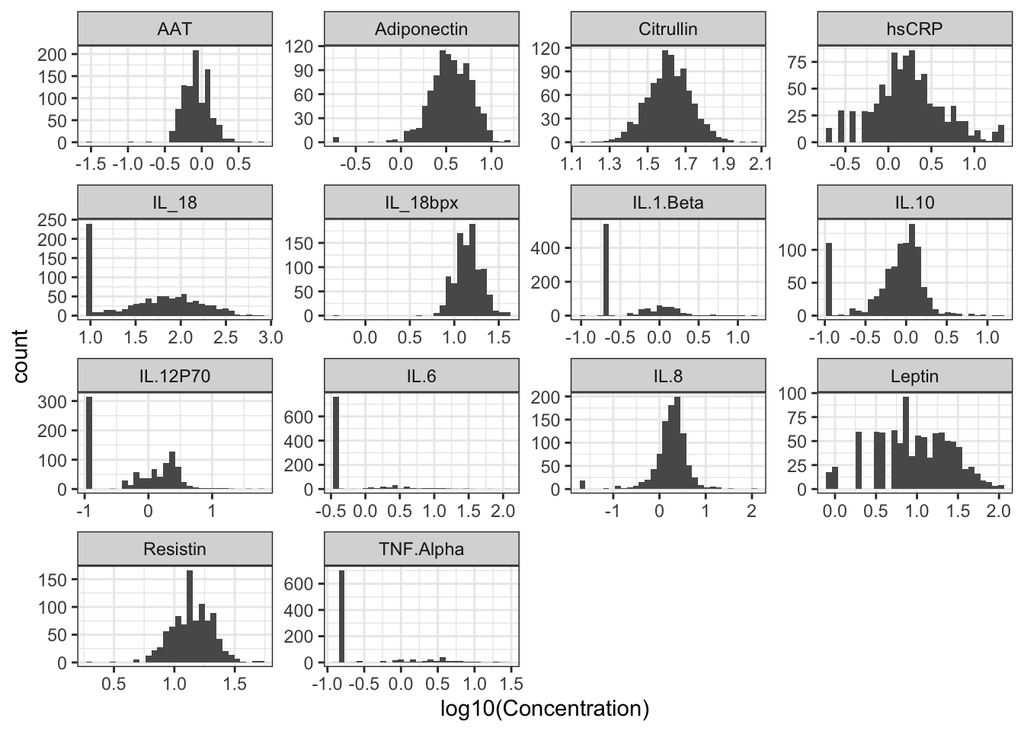

```r
Cytokines %>% gather(Cytokine, Concentration ,2:dim(Cytokines)[2]) %>% ggplot(aes(x= log10(Concentration) )) + geom_histogram() + theme_bw() + facet_wrap(~Cytokine, scales="free")
```

```r
set.seed(76)

Cytokines %>% dplyr::select(-ID) %>% apply(2,log10) %>% as_tibble() %>% apply(2, function(x){ x[x==min(x)] = NA ; return(x) } )  %>% as_tibble() %>% mutate(ID = Cytokines$ID) -> Add_cytokines
left_join( dplyr::select(Covariates, c(ID, Age, Sex, CMV_prediction)) , Add_cytokines, by="ID") -> For_association
left_join(For_association, Top_PCs, by="ID") -> For_association #If cell count correction is wanted
For_association[sapply(For_association, is.infinite)] <- NA


Permutations_3 = function( F_A, Cyto, Real_P, N_Permutations=100 ){
  #We will calculate FDR values through permutation
  Null_distribution = c()
  for (Permutation_n in seq(N_Permutations) ){
    #print( paste0("Permutation: ", Permutation_n ) )

    F_A_permuted = F_A
    F_A_permuted$CMV_prediction =  sample(F_A_permuted$CMV_prediction, size = dim(F_A_permuted)[1], replace=F )

    Basic_association2(F_A_permuted, Cyto)  -> Permuted_results
    Null_distribution = c(Null_distribution, Permuted_results$`Pr(>|t|)`)
  }

  FDRs = Compute_FDR2(Real_P, Null_distribution , N_Permutations)

  return(FDRs)
}


Basic_association2(For_association, Cytokines) %>% arrange(`Pr(>|t|)`) -> Cyto_association
Permutations_3(For_association, Add_cytokines, Cyto_association$`Pr(>|t|)`, 1000) -> FDR_p
Cyto_association %>% mutate(FDR_perm = FDR_p) -> Cyto_association
print(Cyto_association)
```

```
## # A tibble: 14 × 7
##     Estimate `Std. Error` `t value` `Pr(>|t|)` Cytokine    Sample_n FDR_perm
##        <dbl>        <dbl>     <dbl>      <dbl> <chr>          <int>    <dbl>
##  1  0.0409         0.0129    3.16      0.00166 IL_18bpx         701    0.031
##  2  0.0224         0.0146    1.54      0.125   Resistin         701    0.858
##  3 -0.0445         0.0308   -1.44      0.149   IL.8             686    0.680
##  4  0.119          0.0958    1.24      0.217   IL.6             139    0.739
##  5 -0.0391         0.0515   -0.758     0.448   TNF.Alpha        700    1
##  6  0.0230         0.0398    0.578     0.564   IL_18            527    1
##  7  0.0161         0.0328    0.490     0.625   Leptin           690    1
##  8  0.0175         0.0371    0.473     0.637   hsCRP            694    1
##  9  0.00976        0.0379    0.257     0.797   IL.1.Beta        701    1
## 10 -0.00582        0.0234   -0.248     0.804   IL.10            618    1
## 11 -0.000587       0.0106   -0.0552    0.956   Citrullin        700    1
## 12  0.00163        0.0360    0.0452    0.964   IL.12P70         476    1
## 13 -0.000835       0.0188   -0.0444    0.965   Adiponectin      697    1
## 14 -0.000295       0.0160   -0.0184    0.985   AAT              700    0.984
```

```r
write_tsv(Cyto_association, paste0(Location_dir, "Results/CMV_Cytokines.tsv"))
```

Residuals of 0-inflated distributions dont look fine. I believe we might be seing some lower limit detention problems (min of TNF-alpha is 0.16 in many samples, 0.21 for IL.1.Beta …).

We find that CMV infection is significantly associated with higher levels of IL_18BP (0.0409, P=0.00166, FDR_bh=0.0232, FDR_1000=0.031). Tolerogenic response. This cytokine’s distribution looks ok.

Next, we will explore the OLINK CVD proteomic panel.

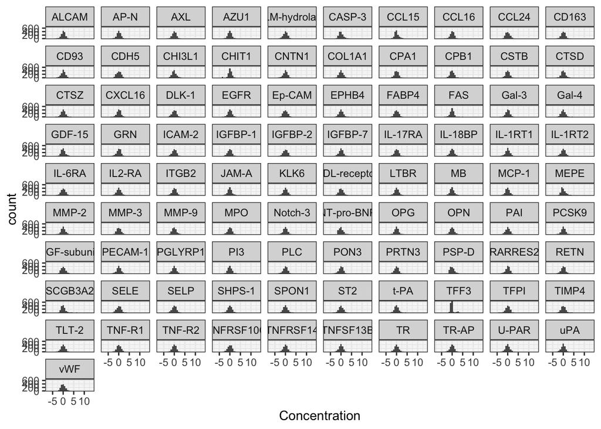

```r
###PREPARE DATA #####
#Olink data is already log10 transformed
Proteomics %>% dplyr::select(-ID) %>% apply(2, function(x){ as.numeric(x) } ) %>% as_tibble() %>% mutate(ID = Proteomics$ID) %>% left_join(dplyr::select(Covariates, c(ID, CMV_prediction, Age, Sex)) , .) %>% drop_na()  -> DF_p_uncorrected


#Not-adjusted data
DF_p_uncorrected[sapply(DF_p_uncorrected, is.infinite)] <- NA
DF_p_uncorrected %>% drop_na() -> DF_p_uncorrected
DF_p_uncorrected %>% dplyr::select(-c(CMV_prediction, Sex, ID)) %>% apply(2, scale) %>% as_tibble() %>% mutate(CMV_prediction = DF_p_uncorrected$CMV_prediction, Sex= DF_p_uncorrected$Sex, ID=DF_p_uncorrected$ID) -> DF_p_uncorrected
Saved_IDs_un = DF_p_uncorrected$ID
#Add cell composition covariates
left_join(DF_p_uncorrected, Top_PCs) %>% dplyr::select(-ID) %>% drop_na() -> DF_p_uncorrected_PCs
DF_p_uncorrected %>% dplyr::select(-ID) -> DF_p_uncorrected

DF_p_uncorrected %>% select(-c(Age, Sex, CMV_prediction)) %>% gather(Protein, Concentration) %>% ggplot(aes(x=Concentration)) + geom_histogram() + theme_bw() + facet_wrap(~Protein)
```

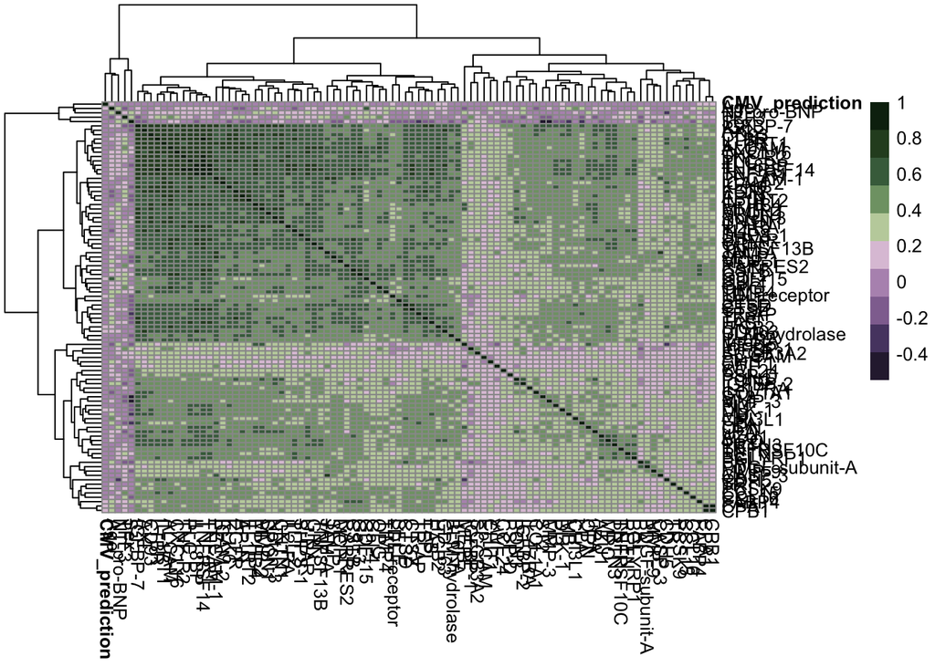

```r
DF_p_uncorrected  %>% mutate(CMV_prediction = as.numeric(CMV_prediction)) %>% cor() -> For_plot
For_plot %>% pheatmap::pheatmap(labels_row = make_bold_names(For_plot, rownames, c("CMV_prediction")), labels_col = make_bold_names(For_plot, colnames, c("CMV_prediction") ), color = met.brewer(name="Cassatt2", type="continuous") )
```

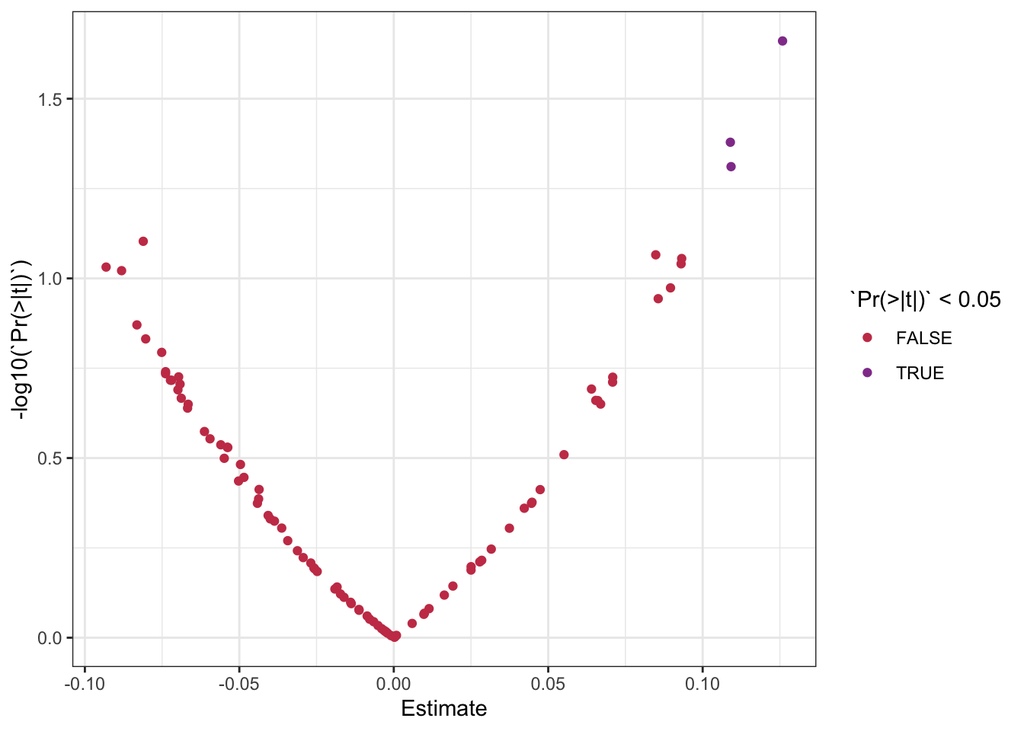

```r
Assoc_Protein = function(DF = DF_p, Covariates_u = F ){
  Association_proteomics = tibble()
  for (Protein in  colnames(DF) ){
    if (Protein %in% c("ID", "Sex", "Age", "CMV_prediction")){ next }
    if (Covariates_u == T){
      Formula = as.formula( paste0("`", Protein, "` ~ Age + Sex + CMV_prediction" ) )
    } else {
      Formula = as.formula( paste0("`", Protein, "` ~ CMV_prediction" ) )
    }
    lm(Formula, DF) %>% summary() -> temp_result
    temp_result$coefficients %>% as_tibble() %>% tail(1) %>%   mutate(Protein = Protein) -> temp_result
    rbind(Association_proteomics, temp_result) -> Association_proteomics
  }
  return(Association_proteomics)
}
Get_Permutation_FDR = function(Assocation_proteomics,DF, Permutations=100, Use_covariate=F){
  set.seed(87)
  N_perm = Permutations
  Permuted_ps = c()
  for (Permutation in 1:N_perm){
    Permuted_cmv = sample(DF$CMV_prediction, replace=F, size = dim(DF)[1] )
     Permuted = Assoc_Protein(mutate(DF, CMV_prediction=Permuted_cmv ), Covariates_u=Use_covariate)
    Permuted_ps = c(Permuted_ps, Permuted$`Pr(>|t|)`)
  }

  FDR = Compute_FDR2(Association_proteomics$`Pr(>|t|)`, Permuted_ps , Permutations)
  Association_proteomics %>% mutate(FDR_permutation = FDR) %>% arrange(`Pr(>|t|)`) -> Association_proteomics
  return(Association_proteomics)
}

#Assocations
Association_proteomics = Assoc_Protein(DF_p_uncorrected, Covariates_u = T   )
#Get FDR
Association_proteomics = Get_Permutation_FDR(Association_proteomics,DF_p_uncorrected, Permutations = 1000)
#Plotting volcano plot
Association_proteomics %>% ggplot(aes(x=Estimate, y=-log10(`Pr(>|t|)` ), col = `Pr(>|t|)`<0.05 )) + geom_point() +theme_bw() + scale_color_discrete(type = met.brewer(name="Klimt", n=2,type="discrete") )
```

```r
print(Association_proteomics)
```

```
## # A tibble: 91 × 6
##    Estimate `Std. Error` `t value` `Pr(>|t|)` Protein       FDR_permutation
##       <dbl>        <dbl>     <dbl>      <dbl> <chr>                   <dbl>
##  1   0.126        0.0548      2.30     0.0218 ITGB2                  0.0621
##  2   0.109        0.0535      2.04     0.0418 DLK-1                  0.0592
##  3   0.109        0.0554      1.97     0.0489 TR                     0.0855
##  4  -0.0811       0.0461     -1.76     0.0788 MMP-3                  0.322
##  5   0.0848       0.0494      1.72     0.0860 FABP4                  0.126
##  6   0.0932       0.0546      1.71     0.0880 BLM-hydrolase          0.208
##  7   0.0930       0.0550      1.69     0.0911 AXL                    0.128
##  8  -0.0931       0.0554     -1.68     0.0930 OPN                    0.0989
##  9  -0.0881       0.0528     -1.67     0.0952 IGFBP-1                1
## 10   0.0896       0.0554      1.62     0.106  CDH5                   0.146
## # … with 81 more rows
```

```r
write_tsv(Association_proteomics, paste0(Location_dir, "Results/CMV_Olink.tsv"))
```

No significant findings with Olink proteins

Are there Age-dependent differences in CMV effects on proteomics?

Age different effects of CMV in protein levels

```r
#Add variable to dataset with different age bins
Covariates %>% mutate(Age_group = ifelse(Age < 30, "Twenties", ifelse(Age<40, "Thirties", ifelse(Age<50, "Fourties", ifelse(Age<60, "Fifties", ifelse(Age<70, "Sixties", ifelse(Age<80, "Seventies", NA) ) ) )  )  ) ) -> Covariates
  Covariates %>% mutate(Age_group = factor(Age_group, levels = c("Twenties", "Thirties", "Fourties", "Fifties", "Sixties", "Seventies" ) ) ) -> Covariates
#Add second variable indicating if young (twenties) or elder (seventies)
Covariates %>% mutate(Age_group2 = ifelse(Age_group %in% c("Twenties", "Seventies"), as.factor(Age_group), NA ) ) -> Covariates



#Function for interaction assocaiton
Interaction_age = function(DF_test){
  Age_CMV = tibble()
  N = colnames(DF_test)[colnames(DF_test) %in% colnames(Proteomics) ]
  for (i in N ){
    if (i == "ID"){ next }
    Model = paste0("`",i, "` ~ Sex + Age_group2*CMV_prediction")
    Model0 = paste0("`", i, "` ~ Sex + Age_group2 + CMV_prediction")
    lm(Model, DF_test) -> Model1
    lm(Model0, DF_test) -> Model0
    anova(Model0, Model1) -> A
    tibble(Protein=i , P=  A$`Pr(>F)`) %>% rbind(Age_CMV, . ) ->  Age_CMV
  }
  return(Age_CMV)
}

set.seed(78789)
Age_CMV = Interaction_age(left_join(Proteomics, Covariates )) %>% drop_na()
#Perfomr permutations
Permutation_results = tibble()
N_perm = 1000
for (i in seq(N_perm)){
  Covariates_perm = Covariates

  Covariates_perm$CMV_prediction =  sample(Covariates_perm$CMV_prediction, dim(Covariates_perm)[1], replace=T )
  Covariates_perm$Age_group2 =  sample(Covariates_perm$Age_group2, dim(Covariates_perm)[1], replace=T )

  Interaction_age(left_join(Proteomics, Covariates_perm, by="ID" ))  %>% drop_na()  %>% rbind(Permutation_results, . ) -> Permutation_results
}
FDRs = Compute_FDR2(Age_CMV$P, Permutation_results , N_perm)
Age_CMV %>% mutate(FDR_p = FDRs) %>% arrange(P) -> Age_CMV

#Get effect size for the signifcant assocaiton
lm(`PSP-D` ~ Sex+as.factor(Age_group2)*CMV_prediction, left_join(Proteomics, Covariates ) ) %>% summary()
```

```
##
## Call:
## lm(formula = `PSP-D` ~ Sex + as.factor(Age_group2) * CMV_prediction,
##     data = left_join(Proteomics, Covariates))
##
## Residuals:
##     Min      1Q  Median      3Q     Max
## -1.3100 -0.4842 -0.1004  0.4603  1.7810
##
## Coefficients:
##                                       Estimate Std. Error t value Pr(>|t|)
## (Intercept)                            5.13419    0.13532  37.942  < 2e-16 ***
## Sex                                   -0.08591    0.07829  -1.097 0.273427
## as.factor(Age_group2)6                -0.05503    0.14607  -0.377 0.706626
## CMV_prediction                        -0.15417    0.09795  -1.574 0.116603
## as.factor(Age_group2)6:CMV_prediction  0.69076    0.20699   3.337 0.000959 ***
## ---
## Signif. codes:  0 '***' 0.001 '**' 0.01 '*' 0.05 '.' 0.1 ' ' 1
##
## Residual standard error: 0.6544 on 285 degrees of freedom
##   (1157 observations deleted due to missingness)
## Multiple R-squared:  0.0675, Adjusted R-squared:  0.05441
## F-statistic: 5.158 on 4 and 285 DF,  p-value: 0.0005024
```

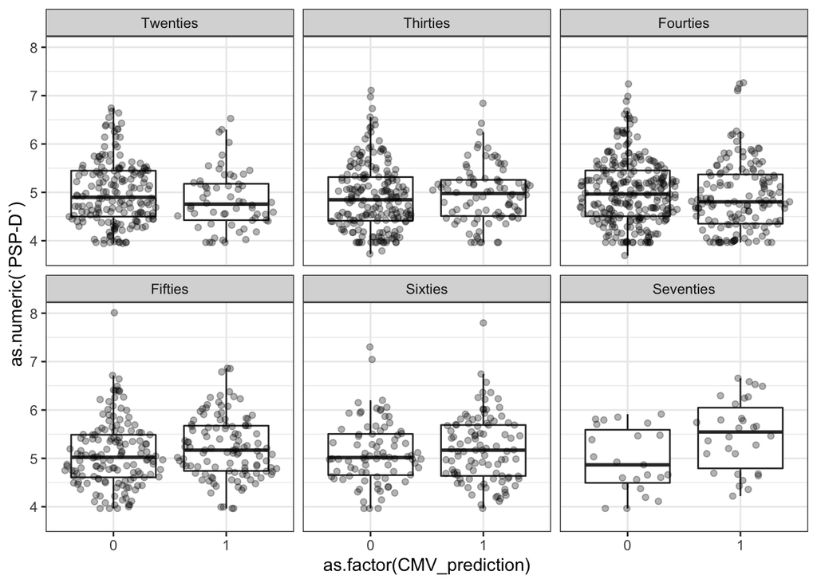

```r
#Plot
 left_join(Proteomics, Covariates ) %>% filter(!is.na(CMV_prediction)) %>% filter(! is.na(Age_group)) %>% ggplot( aes(x=as.factor(CMV_prediction) ,y= as.numeric(`PSP-D`)  ) )  + geom_boxplot(outlier.shape = NA) + ggforce::geom_sina(alpha=0.3)  + facet_wrap(~Age_group) + theme_bw()
```

```r
 left_join(Proteomics, Covariates ) %>% lm(`PSP-D` ~ Sex + Age_group*CMV_prediction, .  ) %>% summary()
```

```
##
## Call:
## lm(formula = `PSP-D` ~ Sex + Age_group * CMV_prediction, data = .)
##
## Residuals:
##      Min       1Q   Median       3Q      Max
## -1.33175 -0.49796 -0.07677  0.42215  2.96298
##
## Coefficients:
##                                    Estimate Std. Error t value Pr(>|t|)
## (Intercept)                        5.188422   0.076435  67.880  < 2e-16 ***
## Sex                               -0.119588   0.035838  -3.337 0.000869 ***
## Age_groupThirties                 -0.101257   0.068906  -1.470 0.141918
## Age_groupFourties                  0.008914   0.064934   0.137 0.890836
## Age_groupFifties                   0.098572   0.074558   1.322 0.186349
## Age_groupSixties                   0.107261   0.088394   1.213 0.225163
## Age_groupSeventies                -0.062404   0.148015  -0.422 0.673375
## CMV_prediction                    -0.156760   0.099657  -1.573 0.115945
## Age_groupThirties:CMV_prediction   0.218049   0.131230   1.662 0.096818 .
## Age_groupFourties:CMV_prediction   0.071903   0.121285   0.593 0.553382
## Age_groupFifties:CMV_prediction    0.286345   0.130192   2.199 0.028010 *
## Age_groupSixties:CMV_prediction    0.244784   0.140117   1.747 0.080854 .
## Age_groupSeventies:CMV_prediction  0.699251   0.210151   3.327 0.000899 ***
## ---
## Signif. codes:  0 '***' 0.001 '**' 0.01 '*' 0.05 '.' 0.1 ' ' 1
##
## Residual standard error: 0.6669 on 1415 degrees of freedom
##   (19 observations deleted due to missingness)
## Multiple R-squared:  0.04201,    Adjusted R-squared:  0.03389
## F-statistic: 5.171 on 12 and 1415 DF,  p-value: 1.516e-08
```

```r
write_tsv(Age_CMV, paste0(Location_dir, "Results/CMV_age_interaction_Olink.tsv"))
```

Next, we will investigate the reasons Females have shorter telomeres. This might be related to a stronger response to CMV. Thus we will check: 1. Do females have more proinflammatory proteins than males when infected? 2. Do females have higher antibody titters?

Females TL are more affected by CMV. We wonder if at the cytokine level we also see different effects in females.

```r
Interaction_association = function(For_association_cytokines){
  Interaction_results = tibble()
  for (Cyto in colnames(dplyr::select(Cytokines, -ID ))){
    Model = paste0("`",Cyto ,"` ~ CMV_prediction + Age + Sex + CMV_prediction:Sex")
    lm(Model, For_association_cytokines) %>% summary() -> Interaction_results_temp
    Interaction_results_temp$coefficients %>% as.data.frame() %>% rownames_to_column("Effect") %>% mutate(Cytokine = Cyto) %>% rbind(Interaction_results, . ) -> Interaction_results
  }
  return(Interaction_results)
}

#1.
left_join(Covariates, Cytokines) -> For_association_cytokines
Interaction_association(For_association_cytokines) ->  Interaction_results
#2. Ranking cytokine levels
For_association_cytokines_rank  = left_join(Covariates, Cytokines %>% dplyr::select(-ID) %>% apply(2, InvRank) %>% as_tibble() %>% mutate(ID = Cytokines$ID) )
```

```r
Interaction_association( For_association_cytokines_rank ) -> Interaction_results_rank
#3. Permutation-based FDR
Do_permutations = function(Interaction_results, shuffle="CMV_and_sex", N_perm=1000){
  set.seed(8744)
  Result_permutation = tibble()
  for ( i in seq(1:N_perm) ){
    print(paste0("Permutation: ", i ))
    Covariates_perm= Covariates
    if (shuffle == "CMV") {
      sample(c(1,0), replace=T , 1448) -> NID
      Covariates_perm$CMV_prediction = NID
    } else if (shuffle == "CMV_and_sex") {
      sample(Covariates_perm$CMV_prediction, replace=T , 1448) -> NID
      sample(Covariates_perm$Sex, replace=T , 1448) -> NID2
      Covariates_perm$CMV_prediction = NID
      Covariates_perm$Sex = NID2
    }
    Interaction_association(left_join(Covariates_perm, Cytokines, by="ID")) %>% rbind(Result_permutation, . ) -> Result_permutation

  }
  Result_permutation %>% filter(grepl(":", Effect)) -> Result_permutation
  #Result_permutation %>% ggplot(aes(x=`Pr(>|t|)` )) + geom_histogram() + theme_bw() + facet_wrap(~Cytokine)

  # calculate FDR for each observed P-value
  FDRs = Compute_FDR2(Interaction_results$`Pr(>|t|)`, Result_permutation$`Pr(>|t|)` , N_perm)
  return(Interaction_results %>% mutate(FDR_p = FDRs))
}

#Results using the rank-based approach
Interaction_results_rank %>% filter(grepl(":", Effect)) -> Interaction_results_rank
Do_permutations(Interaction_results_rank, N_perm = 1000 )  -> Interaction_results_rank
```

[output not shown]

[output cut: 985 more lines]

```r
Interaction_results_rank %>% mutate(Model = "Rank") %>% as_tibble() %>% arrange(`Pr(>|t|)` ) -> Interaction_results_rank
#Results without rank
Interaction_results %>% filter(grepl(":", Effect)) -> Interaction_results
Do_permutations(Interaction_results ) -> Interaction_results
```

[output not shown]

[output cut: 985 more lines]

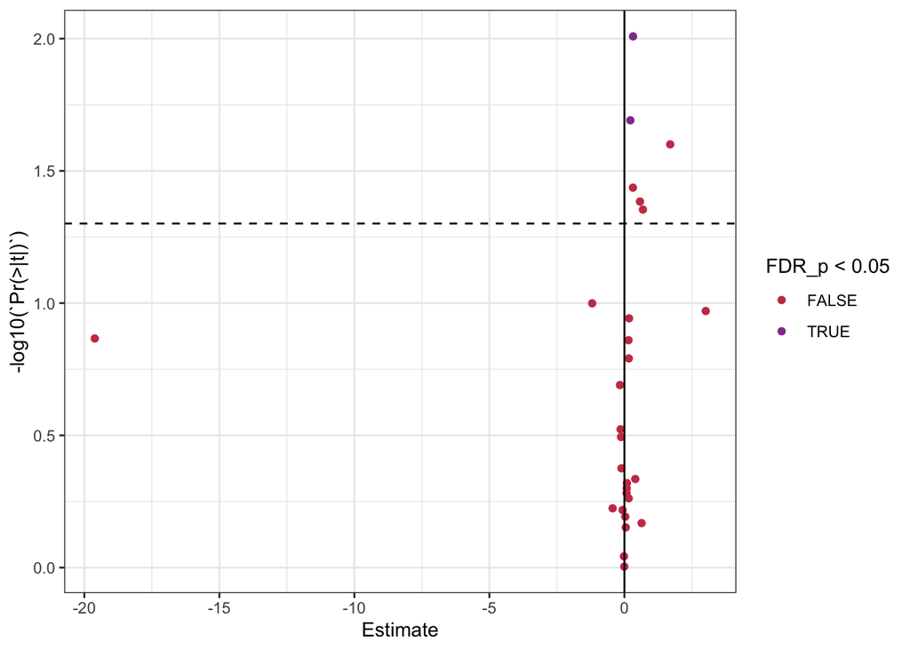

```r
Interaction_results %>% mutate(Model = "Rank") %>% as_tibble() %>% arrange(`Pr(>|t|)` )  -> Interaction_results
#Combine both
left_join(Interaction_results_rank %>% select(-Model),Interaction_results %>% select(-Model) , by=c("Effect","Cytokine"), suffix=c("_rankedCytokine","")  ) %>% arrange(`Pr(>|t|)_rankedCytokine`) -> For_Save
rbind(Interaction_results_rank,Interaction_results )  -> Interaction_results_all
#Save
For_Save  %>% write_tsv(. , path = paste0(Location_dir, "Results/CMV_cytokine_sex_interaction.tsv"))

#Volcano plot
Interaction_results_all %>% filter(Model=="Rank") %>% ggplot(aes(x=Estimate, y=-log10(`Pr(>|t|)`), col = FDR_p<0.05 )) + geom_point() + theme_bw() + geom_vline(xintercept = 0) + geom_hline(yintercept = -log10(0.05), linetype=2) +scale_color_manual(values = c(met.brewer(name="Klimt", n=2,type="discrete")) ) #+ facet_wrap(~Model, scales = "free")
```

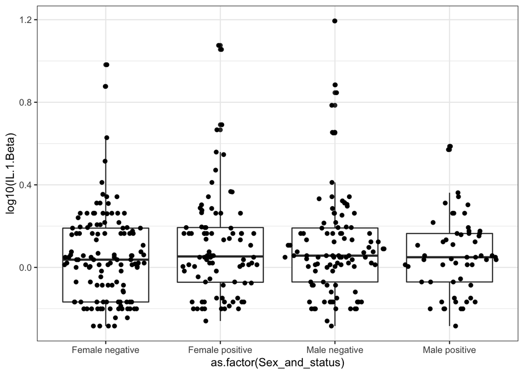

```r
#Plots sex dependent assocaiton
#Prepare data
For_association_cytokines %>% mutate(Sex_and_status = ifelse(CMV_prediction==1 & Sex ==2, "Female positive", ifelse(CMV_prediction==1 & Sex==1, "Male positive", ifelse(CMV_prediction==0 & Sex==2, "Female negative", "Male negative") ) ) ) -> For_plot
left_join(Covariates, Cytokines %>% select(-ID) %>% apply(2, InvRank) %>% as_tibble() %>% mutate(ID = Cytokines$ID) )  %>% mutate(Sex_and_status = ifelse(CMV_prediction==1 & Sex ==2, "Female positive", ifelse(CMV_prediction==1 & Sex==1, "Male positive", ifelse(CMV_prediction==0 & Sex==2, "Female negative", "Male negative") ) ) ) -> For_plot2
#plot
For_plot %>% filter(!is.na(Sex_and_status)) %>% filter(`IL.1.Beta` >0.5) %>%  ggplot(aes(x= as.factor(Sex_and_status) , y = log10(`IL.1.Beta`) )) + geom_boxplot() + theme_bw() + ggforce::geom_sina()
```

```r
For_plot2 %>% filter(!is.na(Sex_and_status)) %>% filter(`IL.6` > 0) %>%  ggplot(aes(x= as.factor(Sex_and_status) , y = `IL.6`) ) + geom_boxplot() + theme_bw() + ggforce::geom_sina()+ coord_flip() +  theme(axis.title.y=element_blank() ) -> Il6_int
For_plot2 %>% filter(!is.na(Sex_and_status)) %>% filter(`IL.12P70` > 0) %>%  ggplot(aes(x= as.factor(Sex_and_status) , y = `IL.12P70`) ) + geom_boxplot() + theme_bw() + ggforce::geom_sina() + coord_flip() +  theme(axis.title.y=element_blank() )  -> IL12P70_int

Il6_int | IL12P70_int -> cytokine_plots
ggsave( paste0(Location_dir,"Results/Figures/Sex_cytokine_CMV.pdf"), cytokine_plots)
For_plot2 %>% filter(`IL.12P70` > 0) %>% lm(`IL.12P70` ~ Age + CMV_prediction*Sex, . ) %>% summary()
```

```
##
## Call:
## lm(formula = IL.12P70 ~ Age + CMV_prediction * Sex, data = .)
##
## Residuals:
##      Min       1Q   Median       3Q      Max
## -0.88760 -0.46943 -0.09786  0.35896  2.05694
##
## Coefficients:
##                      Estimate Std. Error t value Pr(>|t|)
## (Intercept)         0.9471830  0.1456538   6.503 2.04e-10 ***
## Age                -0.0003823  0.0021108  -0.181   0.8563
## CMV_prediction     -0.3875837  0.1929548  -2.009   0.0451 *
## Sex                -0.1026641  0.0690624  -1.487   0.1378
## CMV_prediction:Sex  0.2798715  0.1157218   2.418   0.0160 *
## ---
## Signif. codes:  0 '***' 0.001 '**' 0.01 '*' 0.05 '.' 0.1 ' ' 1
##
## Residual standard error: 0.5916 on 465 degrees of freedom
##   (1 observation deleted due to missingness)
## Multiple R-squared:  0.0146, Adjusted R-squared:  0.006121
## F-statistic: 1.722 on 4 and 465 DF,  p-value: 0.1439
```

```r
lm(`IL.12P70` ~ Age + CMV_prediction ,For_association_cytokines_rank %>% filter(Sex==1)  ) %>% summary()
```

```
##
## Call:
## lm(formula = IL.12P70 ~ Age + CMV_prediction, data = For_association_cytokines_rank %>%
##     filter(Sex == 1))
##
## Residuals:
##     Min      1Q  Median      3Q     Max
## -1.3210 -0.8212 -0.1179  0.6037  2.7670
##
## Coefficients:
##                 Estimate Std. Error t value Pr(>|t|)
## (Intercept)     0.507686   0.154496   3.286  0.00111 **
## Age            -0.008677   0.003339  -2.599  0.00972 **
## CMV_prediction -0.176571   0.096187  -1.836  0.06718 .
## ---
## Signif. codes:  0 '***' 0.001 '**' 0.01 '*' 0.05 '.' 0.1 ' ' 1
##
## Residual standard error: 0.9002 on 383 degrees of freedom
##   (225 observations deleted due to missingness)
## Multiple R-squared:  0.02823,    Adjusted R-squared:  0.02316
## F-statistic: 5.564 on 2 and 383 DF,  p-value: 0.004151
```

```r
lm(`IL.12P70` ~ Age + CMV_prediction ,For_association_cytokines_rank %>% filter(Sex==2)  ) %>% summary()
```

```
##
## Call:
## lm(formula = IL.12P70 ~ Age + CMV_prediction, data = For_association_cytokines_rank %>%
##     filter(Sex == 2))
##
## Residuals:
##      Min       1Q   Median       3Q      Max
## -1.16222 -0.93467 -0.03787  0.63598  2.89606
##
## Coefficients:
##                 Estimate Std. Error t value Pr(>|t|)
## (Intercept)     0.148361   0.129307   1.147    0.252
## Age            -0.004072   0.002905  -1.402    0.162
## CMV_prediction  0.125756   0.079363   1.585    0.114
##
## Residual standard error: 0.8935 on 550 degrees of freedom
##   (278 observations deleted due to missingness)
## Multiple R-squared:  0.00684,    Adjusted R-squared:  0.003228
## F-statistic: 1.894 on 2 and 550 DF,  p-value: 0.1515
```

```r
lm(`IL.6` ~ Age + CMV_prediction ,For_association_cytokines_rank %>% filter(Sex==1) ) %>% summary()
```

```
##
## Call:
## lm(formula = IL.6 ~ Age + CMV_prediction, data = For_association_cytokines_rank %>%
##     filter(Sex == 1))
##
## Residuals:
##     Min      1Q  Median      3Q     Max
## -0.5546 -0.4191 -0.3545 -0.2372  2.6579
##
## Coefficients:
##                 Estimate Std. Error t value Pr(>|t|)
## (Intercept)     0.026620   0.128226   0.208    0.836
## Age             0.003475   0.002771   1.254    0.211
## CMV_prediction -0.127116   0.079832  -1.592    0.112
##
## Residual standard error: 0.7471 on 383 degrees of freedom
##   (225 observations deleted due to missingness)
## Multiple R-squared:  0.009729,   Adjusted R-squared:  0.004558
## F-statistic: 1.881 on 2 and 383 DF,  p-value: 0.1538
```

```r
lm(`IL.6` ~ Age + CMV_prediction ,For_association_cytokines_rank %>% filter(Sex==2) ) %>% summary()
```

```
##
## Call:
## lm(formula = IL.6 ~ Age + CMV_prediction, data = For_association_cytokines_rank %>%
##     filter(Sex == 2))
##
## Residuals:
##     Min      1Q  Median      3Q     Max
## -0.3956 -0.3293 -0.2506 -0.2183  3.1578
##
## Coefficients:
##                 Estimate Std. Error t value Pr(>|t|)
## (Intercept)    -0.070326   0.092967  -0.756   0.4497
## Age             0.001618   0.002089   0.775   0.4387
## CMV_prediction  0.099686   0.057059   1.747   0.0812 .
## ---
## Signif. codes:  0 '***' 0.001 '**' 0.01 '*' 0.05 '.' 0.1 ' ' 1
##
## Residual standard error: 0.6424 on 550 degrees of freedom
##   (278 observations deleted due to missingness)
## Multiple R-squared:  0.007748,   Adjusted R-squared:  0.00414
## F-statistic: 2.147 on 2 and 550 DF,  p-value: 0.1178
```

There are two significant results if rank, none if not ranked.

Do females also show higher levels of CMV titters than males?

```r
  All_alr = read_rds( paste0(Location_dir,"Data/Quantifiaction_PhIPseq_alr.rds") )
  cmv_peptides <- read_tsv(paste0(Location_dir, "Results/CMV_peptides.tsv"))
  cmv_peptides <- cmv_peptides$Peptide


  All_alr %>% filter(grepl("LLD", ID)) %>% filter(! grepl("_F", ID) ) -> All_alr
  All_alr %>% filter(ID %in% filter(Covariates, CMV_prediction == 1)$ID ) %>% dplyr::select(c("ID", cmv_peptides)) -> Titters
```

```
## Note: Using an external vector in selections is ambiguous.
## ℹ Use `all_of(cmv_peptides)` instead of `cmv_peptides` to silence this message.
## ℹ See <https://tidyselect.r-lib.org/reference/faq-external-vector.html>.
```

```r
  Titters %>% left_join(Covariates %>% select(ID, Sex, Age )) -> Titters_test
```

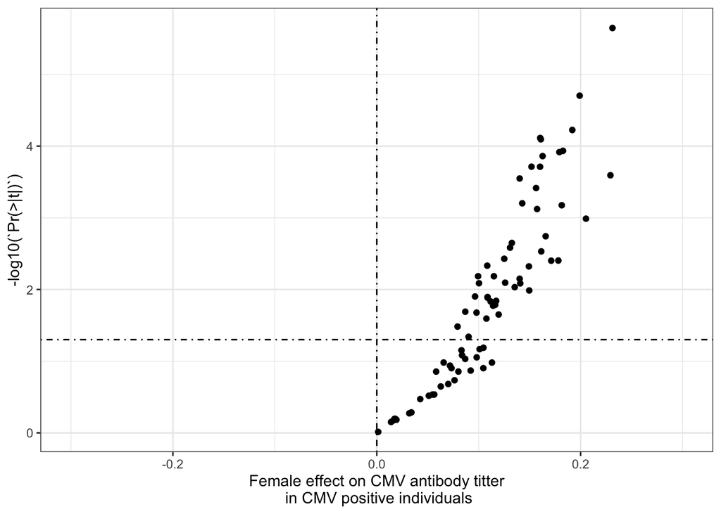

```r
  Association_titters = tibble()
  for (Peptide in colnames(Titters)){
    if (Peptide == "ID"){ next }
    Model = paste0(Peptide, " ~ Sex + Age")
    lm(Model, Titters_test) %>% summary() -> Model
    Model$coefficients %>% as.data.frame() %>% rownames_to_column("Value") %>% filter(Value == "Sex") %>% dplyr::select(-Value) %>% as_tibble() %>% mutate(Peptide = Peptide) %>% rbind(Association_titters, . ) -> Association_titters
  }
  write_tsv(Association_titters, paste0(Location_dir,"Results/CMV_titters_vs_female.tsv"))
  Association_titters %>% arrange(`Pr(>|t|)`) %>% ggplot(aes(x=Estimate, y=-log10(`Pr(>|t|)`) )) + theme_bw() + geom_point() + xlab("Female effect on CMV antibody titter\n in CMV positive individuals") + xlim(-0.30, 0.3) + geom_vline(xintercept = 0,linetype="dotdash") + geom_hline(yintercept = -log10(0.05), linetype= "dotdash") -> Figure_titer
  ggsave(paste0(Location_dir,"Results/Figures/SexTiterDifferences_CMVPositive.pdf"), Figure_titer)
  Association_titters %>% arrange(`Pr(>|t|)`) %>% write_tsv(. , path = paste0(Location_dir, "Results/CMV_vs_Titters.tsv"))
  Figure_titer
```

Replication of sex differences in titters

```r
#CMV measurements.
read_excel(  paste0(Location_dir,"Data/Replication/300BCG/2019 300BCG serologies_for_sergio.xlsx")) -> Info_serology_300bcg #Laurent Gillet’s lab measurements
read_excel( paste0(Location_dir,"Data/Replication/300BCG/CMV IgG index 300BCG.xlsx"), sheet= "CMV_for_R") -> Info_serology_300bcg2 #JCI Olink paper (‘PMID: 32692728’)
load( paste0(Location_dir,"Data/Replication/300BCG/data.Robj"), verbose=T) #Metadata from the cohort. Downloaded from 'PMID: 32692728’ GitLab's
```

```
## Loading objects:
##   obj
```

```r
obj[[2]] %>% as_tibble() -> metadata_300bcg


metadata_300bcg %>% rename(PatientID = `Patient,ID`) %>% left_join(Info_serology_300bcg) -> Replication_300bcg
left_join(Replication_300bcg, Info_serology_300bcg2 ) -> Replication_300bcg2
```

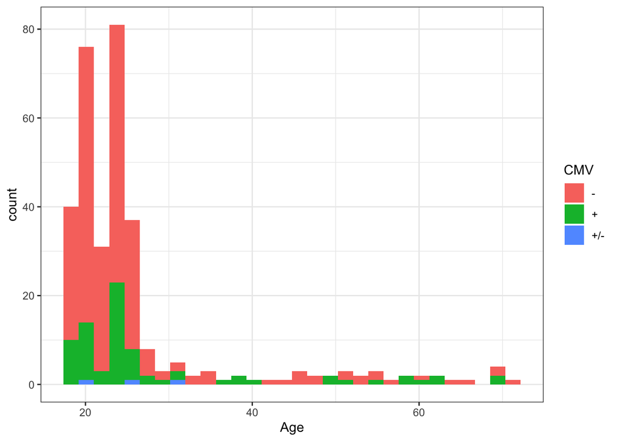

```r
#Check age and sex
Replication_300bcg %>% ggplot(aes(x=Age, fill=CMV )) + geom_histogram() + theme_bw()
```

```r
Replication_300bcg$Gender %>% table()
```

```
## .
## female   male
##    182    139
```

```r
#Check that IDs are good by checking age and sex assocasiations
Replication_300bcg %>% filter(CMV %in% c("+", "-") ) %>%  glm( as.factor(CMV) ~ Gender + Age, . , family=binomial()) %>% summary() # relative assocaiton, not too strong
```

```
##
## Call:
## glm(formula = as.factor(CMV) ~ Gender + Age, family = binomial(),
##     data = .)
##
## Deviance Residuals:
##     Min       1Q   Median       3Q      Max
## -1.1867  -0.7119  -0.6942  -0.6697   1.8025
##
## Coefficients:
##             Estimate Std. Error z value Pr(>|z|)
## (Intercept) -1.86545    0.33522  -5.565 2.62e-08 ***
## Gendermale  -0.02419    0.26989  -0.090   0.9286
## Age          0.02692    0.01100   2.447   0.0144 *
## ---
## Signif. codes:  0 '***' 0.001 '**' 0.01 '*' 0.05 '.' 0.1 ' ' 1
##
## (Dispersion parameter for binomial family taken to be 1)
##
##     Null deviance: 349.75  on 317  degrees of freedom
## Residual deviance: 343.98  on 315  degrees of freedom
## AIC: 349.98
##
## Number of Fisher Scoring iterations: 4
```

```r
#Check for titter assocaitons with females
Replication_300bcg %>% filter(CMV == "+" ) %>% lm(`CMV ELISA` ~ Gender, . ) %>% summary() #Negative but not significant
```

```
##
## Call:
## lm(formula = `CMV ELISA` ~ Gender, data = .)
##
## Residuals:
##      Min       1Q   Median       3Q      Max
## -0.65519 -0.10531  0.01811  0.16681  0.37426
##
## Coefficients:
##             Estimate Std. Error t value Pr(>|t|)
## (Intercept)  0.97869    0.03546   27.60   <2e-16 ***
## Gendermale  -0.01270    0.05301   -0.24    0.811
## ---
## Signif. codes:  0 '***' 0.001 '**' 0.01 '*' 0.05 '.' 0.1 ' ' 1
##
## Residual standard error: 0.2298 on 74 degrees of freedom
## Multiple R-squared:  0.000775,   Adjusted R-squared:  -0.01273
## F-statistic: 0.05739 on 1 and 74 DF,  p-value: 0.8113
```

```r
#This assocation is not significant at all. However, data from 32692728 is more promising
Replication_300bcg2 %>% filter(CMV_status == "Positive" ) %>%  mutate(CMV_IgG_IU_ml = as.numeric(CMV_IgG_IU_ml))  %>% lm( CMV_IgG_IU_ml ~ Gender + Age , . )  %>% summary()  #IgG titters
```

```
##
## Call:
## lm(formula = CMV_IgG_IU_ml ~ Gender + Age, data = .)
##
## Residuals:
##    Min     1Q Median     3Q    Max
## -7.431 -3.329 -1.188  2.549  9.103
##
## Coefficients:
##             Estimate Std. Error t value Pr(>|t|)
## (Intercept)  7.26351    1.23621   5.876 1.16e-07 ***
## Gendermale  -1.08205    0.98943  -1.094    0.278
## Age          0.15087    0.03648   4.135 9.36e-05 ***
## ---
## Signif. codes:  0 '***' 0.001 '**' 0.01 '*' 0.05 '.' 0.1 ' ' 1
##
## Residual standard error: 4.289 on 73 degrees of freedom
## Multiple R-squared:  0.2007, Adjusted R-squared:  0.1788
## F-statistic: 9.163 on 2 and 73 DF,  p-value: 0.0002816
```

```r
Replication_300bcg2 %>% filter(CMV_status == "Positive" ) %>%  mutate(CMV_IgG_Index = as.numeric(CMV_IgG_Index))  %>% lm( CMV_IgG_Index ~ Gender + Age , . )  %>% summary() #IgG index
```

```
##
## Call:
## lm(formula = CMV_IgG_Index ~ Gender + Age, data = .)
##
## Residuals:
##     Min      1Q  Median      3Q     Max
## -4.9070 -2.0201 -0.4716  1.6581  6.3066
##
## Coefficients:
##             Estimate Std. Error t value Pr(>|t|)
## (Intercept)   3.5907     0.7387   4.861 6.51e-06 ***
## Gendermale   -0.3136     0.5913  -0.530 0.597461
## Age           0.0883     0.0218   4.050 0.000126 ***
## ---
## Signif. codes:  0 '***' 0.001 '**' 0.01 '*' 0.05 '.' 0.1 ' ' 1
##
## Residual standard error: 2.563 on 73 degrees of freedom
## Multiple R-squared:  0.1862, Adjusted R-squared:  0.1639
## F-statistic:  8.35 on 2 and 73 DF,  p-value: 0.0005426
```

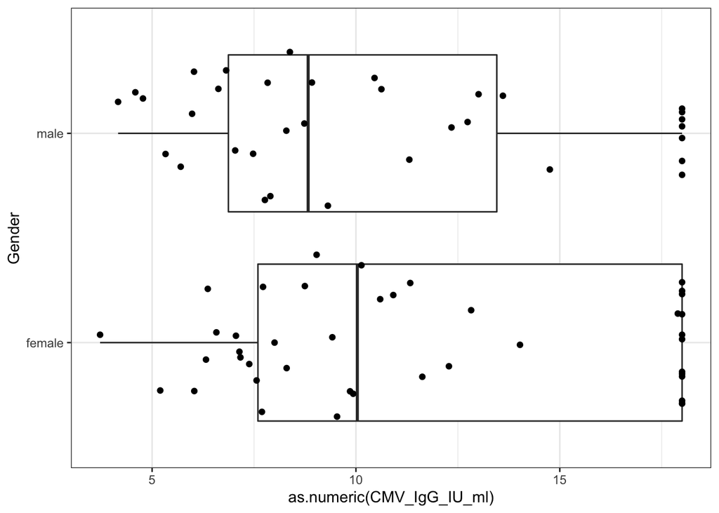

```r
#PLOTS
Replication_300bcg2 %>% filter(CMV_status == "Positive" ) %>% ggplot(aes(x=Gender, y = as.numeric(CMV_IgG_IU_ml))) + geom_boxplot() + theme_bw() + geom_sina() + coord_flip() #Seems like there is a an upper limit in Units per ml
```

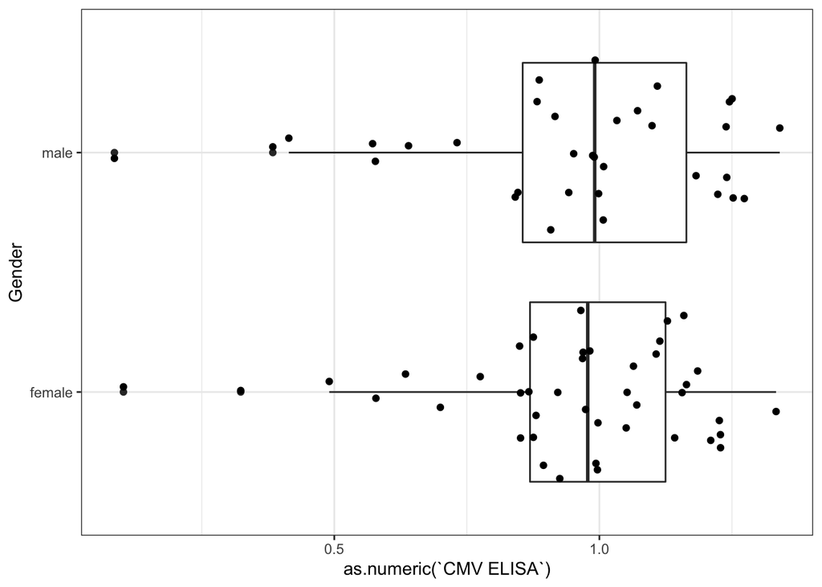

```r
Replication_300bcg2 %>% filter(CMV_status == "Positive" ) %>% ggplot(aes(x=Gender, y = as.numeric(`CMV ELISA`))) + geom_boxplot() + theme_bw() + geom_sina() + coord_flip()
```

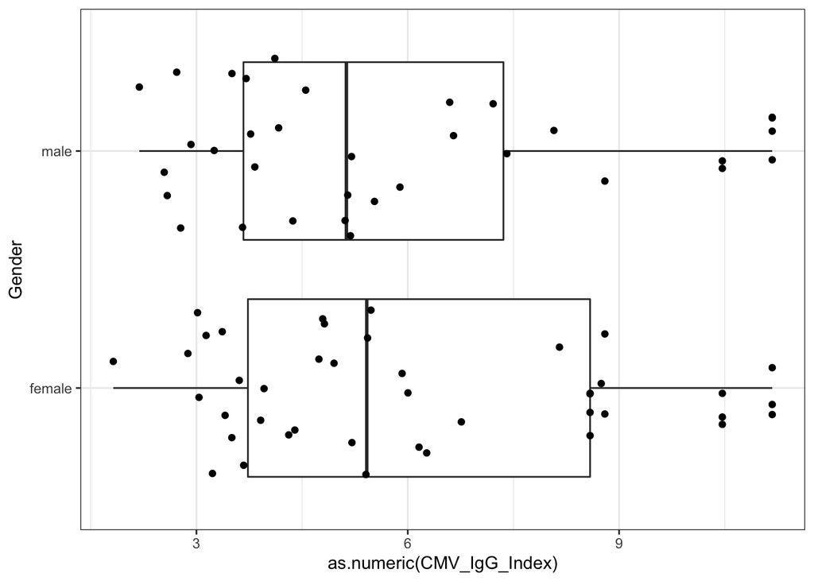

```r
Replication_300bcg2 %>% filter(CMV_status == "Positive" ) %>% ggplot(aes(x=Gender, y = as.numeric(`CMV_IgG_Index`))) + geom_boxplot() + theme_bw() + geom_sina() + coord_flip()
```

Replciation in 500FG?